# Chicago Community Crime Analysis

# Arrests on the watch zone

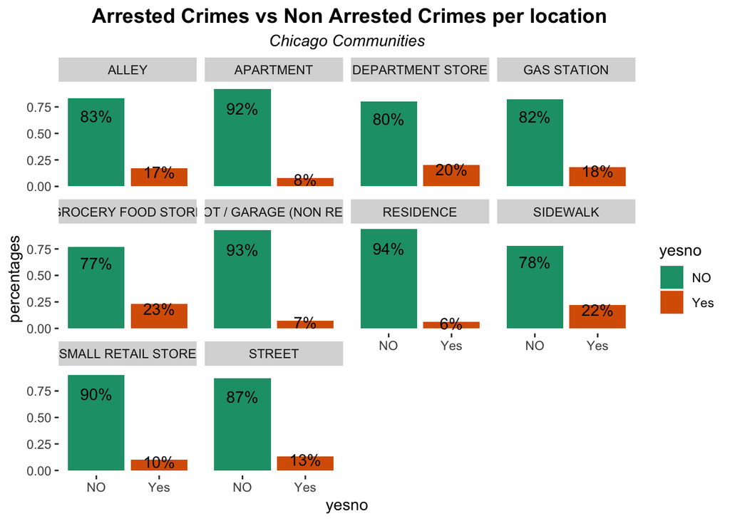

The highest arrests have been made at grocery stores, sidewalks, departments stores and generally in public places. as Apartment arrests are very few compared to other arrests with an 8% arrest rate and a 92% rate of no arrests. This can imply many things such as:

- Most crimes occur on the street
- Offenders usually free the crime scense
- The police does not always arrive in time to catch appartment level crimes

[figure not shown]

## The highest crimes occur on:

This shows that there is a massive gap in arresting offenders who commit crimes in appartments and private places. As demonstrated in the previous chart, only 8% of offenders were arrested and 92% were not.

## KEYWORDS explained:

#### Battery:

unlawful application of force directly or indirectly upon another person or their personal belongings, causing bodily injury or offensive contact.

#### Criminal Damage:

intentionally damaging property that belongs to someone else, including public property.

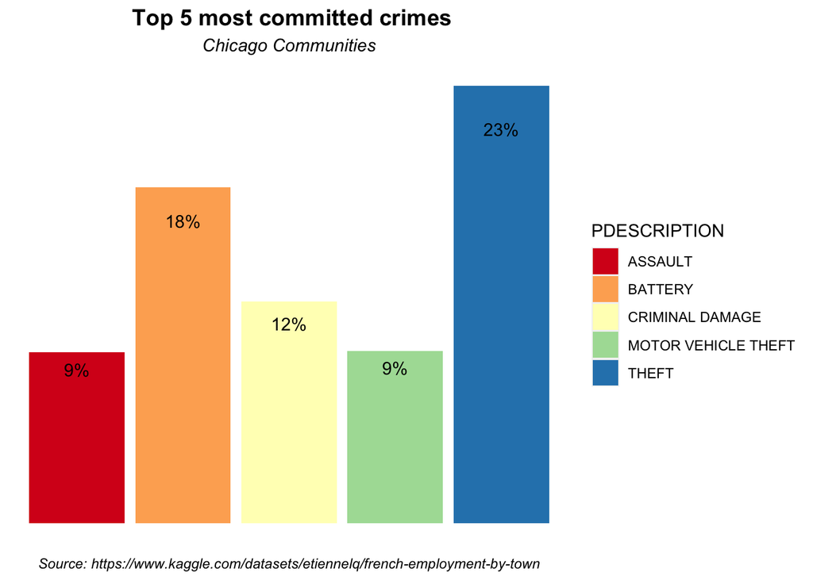

Public crimes can be easier to detect and report. However crimes like battery and criminal damage may also be occur in private places. This is an issue because private places require advanced monitoring.

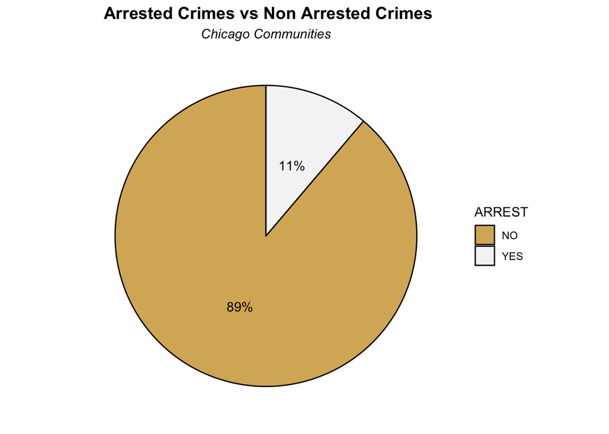

- There is an undeniable gap between arrests made and those not effectuated.
- There is a need to identify whether offenders are fleeing or there is other kinds of limitations that are occurring to limit arrests, or if there is an alternative need.

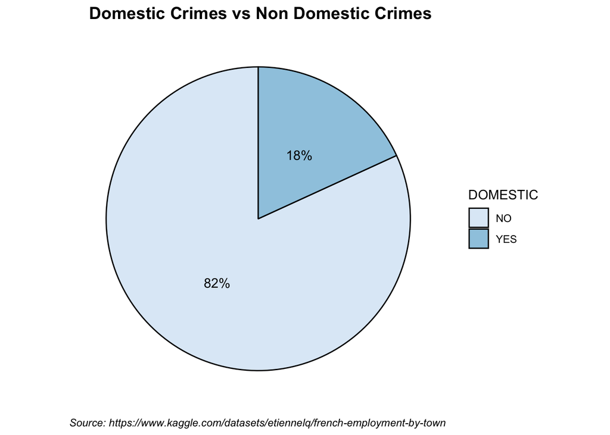

This Diagram shows that while domestic offenses are occuring, a higher number of offenses are occurring outside of private residences. However there is still an abnormal gap level between arrests occurring and not occurring.